# BR02

Xinqian Cai

2021/9/26

## Exercise 2.1

1. $$P(B|A) > P(B)$$
   If a person enjoy an award-winning books, it means that he likes this author’s writing style. Therefore, he will be more probable to be interested in the same author’s book.
2. $$P(B|A) < P(B)$$
   Given today’s temperature is 0 degrees Fahrenheit, it is less likely that tomorrow’s temperature will suddenly get to 60 degrees.
3. $$P(B|A) > P(B)$$
   If the authors only got 3 hours of sleep last night, it will be more likely that the authors will make several typos today because sleeping less will cause disattraction.
4. $$P(B|A) > P(B)$$
   If my friend includes three hashtags in their tweets, the tweet is more likely to get retweeted. Because the more the number of hashtags is, the more people see this tweet.

## Exercise 2.2

1. $$P(B|A) = 0.73$$
   This is a conditional probability.
2. $$P(A) = 0.2$$
   This is a marginal probability.
3. $$P(D) = 0.15$$
   This is a marginal probability.
4. $$P(C|D) = 0.91$$
   This is a conditional probability.
5. $$P(F∩E)$$
   This is a joint probability.
6. $$P(E|F)$$
   This is a conditional probability.

## Exercise 2.3

1. $$Y|π ∼ Bin(6,π)$$
2. $$Y|0.9 ∼ Bin(27,0.9)$$
3. $$Y|0.17 ∼ Bin(n,0.17)$$
4. The binomial model is not appropriate here because I do not know whether Henry has the equal probability of be late each time.
5. $$Y|π(hate to be center) ∼ Bin(n,π)$$
6. $$Y|0.8 ∼ Bin(60,0.8)$$

## Exercise 2.4

```r
ve <- 0.05
nve <- 0.95
sp_ve <- 0.7
sp_nve <- 0.03
ve_sp <- ve*sp_ve/(ve*sp_ve+nve*sp_nve)
ve_sp
```

```
## [1] 0.5511811
```

Given that Edward sparkled like a diamond, the probability that vampire exist is about 55.12%.

## Exercise 2.5

1. The prior probability that the selected tree has mold is 18%.

```r
inf <- 0.18
inf_maple <- 0.8
ninf <- 0.82
ninf_maple <- 0.1

mapple <- inf*inf_maple + ninf*ninf_maple
mapple
```

```
## [1] 0.226
```

The probability that the employee would have selected a maple is 22.6%.

```r
inf*inf_maple/(inf_maple*inf + ninf_maple*ninf)
```

```
## [1] 0.6371681
```

The posterior probability that the elected maple tree has mold is about 63.7%.

## Exercise 2.6

The necessary information is the percentage of fewer than 4 stars restaurant among the restaurants Sandra does not like.

## Exercise 2.7

```r
right <- 0.08
nright <- 0.92
r_nonbinary <- 0.2
nr_nonbinary <- 0.1

nonbinary <- right*r_nonbinary + nright*nr_nonbinary
nonbinary
```

```
## [1] 0.108
```

The probability that a randomly chosen person on this dating app is nonbinary is 10.8%.

```r
right*r_nonbinary/(right*r_nonbinary + nright*nr_nonbinary)
```

```
## [1] 0.1481481
```

The posterior probability that he swipes right given that the profile is nonbinary is about 14.8%.

## Exercise 2.8

```r
del <- 0.15
del_morning <- 0.4
morning <- 0.3

del*del_morning/morning
```

```
## [1] 0.2
```

The probability that Mine’s flight will be delayed is 20%.

```r
ndel <- 0.85
ndel_morning <- (morning - del_morning*del)/ndel
morning*ndel_morning/ndel
```

```
## [1] 0.09965398
```

The probability that Alicia is on a morning flight is 9.965%.

## Exercise 2.9

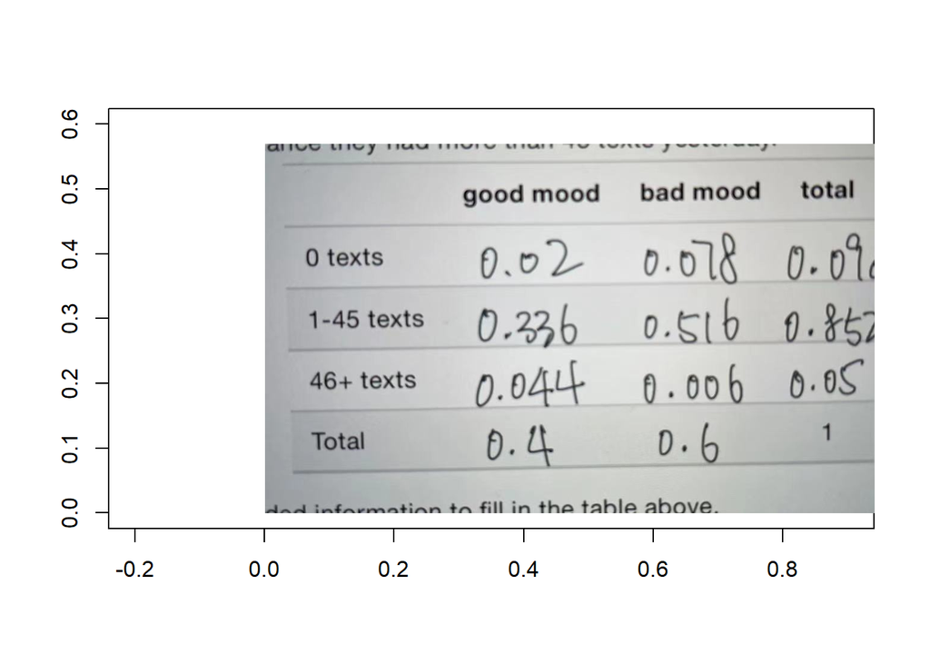

```r
library(png)
diagram <- readPNG("D:/excel01.png")
r <- nrow(diagram)/ncol(diagram)
plot(c(0,0.7), c(0,0.6), type = "n", xlab = "", ylab = "", asp = 1)
rasterImage(diagram, 0, 0, 1, r)
```

b.The probability that the roommate is in a good mood is 40%. This is the prior part of the Bayes’ Rule equation.

3. If they are in good mood today, the probability that they received 50 texts yesterday is 11%. This is the likelihood part.

```r
gm <- 0.4
gm_50 <- 0.11
fiftytexts <- 0.05

gm*gm_50/fiftytexts
```

```
## [1] 0.88
```

Given the roomate received 50 messages yesterday, the posterior probability that they are in a good mood is 88%.

## Exercise 2.10

```r
rural <- 0.085
urban <- 0.0915
rural_L <- 0.1
urban_L <- 0.105

LGBTQ <- rural*rural_L + urban*urban_L
LGBTQ
```

```
## [1] 0.0181075
```

The probability they identify as LGBTQ is about 1.81%

```r
rural*rural_L/LGBTQ
```

```
## [1] 0.4694187
```

If they identify as LGBTQ, the probability that they live in a rural area is about 46.94%.

```r
nLGBTQ <- 1-LGBTQ
rural_nLGBTQ <- 1-rural_L
rural*rural_nLGBTQ/nLGBTQ
```

```
## [1] 0.07791077
```

If they do not identify as LGBTQ, the probability that they live in a rural area is about 7.79%.

## Exercise 2.11

1. $$Y|π ∼ Bin(6,π)$$
   $$f(y|π) = (6 choose y) * π^y * (1-π)^(6-y)$$
   for y∈{0,1,2,3,4,5,6}, π∈{0.3, 0.4, 0.5}

```r
lik_0.3 = choose(6,4)*0.3^4*(0.7^2)
lik_0.3
```

```
## [1] 0.059535
```

3. $$L(π|y = 4) = f(4|π) = (6 choose 4) * π^4 * (1-π)^(6-4)$$
   Exercise 2.12 a.
   $$Y|π ∼ Bin(7,π)$$
   $$f(y|π) = (7 choose y) * π^y * (1-π)^(7-y)$$
   for y∈{0,1,2,3,4,5,6,7}, π∈{0.1, 0.25, 0.4}

```r
p <- c(0.1, 0.25, 0.4)
lik <- dbinom(1,7,p)
lik
```

```
## [1] 0.3720087 0.3114624 0.1306368
```

```r
fy1 <- 0.2*0.372 + 0.45*0.311 +0.35*0.131
fy1
```

```
## [1] 0.2602
```

```r
pmf_0.1 <- 0.2*0.372/fy1
pmf_0.25 <- 0.45*0.311/fy1
pmf_0.4 <- 0.35*0.131/fy1
pmf_0.1
```

```
## [1] 0.2859339
```

```r
pmf_0.25
```

```
## [1] 0.5378555
```

```r
pmf_0.4
```

```
## [1] 0.1762106
```

c.The posterior have likelhood part and nominalizing constant part that the prior model does not have.

```r
fy1_K <- 0.15*0.372 + 0.15*0.311 +0.7*0.131
pmf_0.1 <- 0.15*0.372/fy1_K
pmf_0.25 <- 0.15*0.311/fy1_K
pmf_0.4 <- 0.15*0.131/fy1_K
pmf_0.1
```

```
## [1] 0.2874066
```

```r
pmf_0.25
```

```
## [1] 0.2402781
```

```r
pmf_0.4
```

```
## [1] 0.1012104
```